# Restaurant Complaints vs Inspection Risk in NYC

Do 311 Complaints Signal Food Safety Risk?

Carmine Montaperto, Mary Ononye, Kevin Marcelin, Izabelle Diaz, Kiran Narsipur

2026-05-21

## Motivation

Every year, millions of New Yorkers eat at restaurants without knowing whether the kitchen passed its last health inspection, or whether neighbors have been filing complaints about it for months. New York City’s 311 system receives thousands of food-related complaints annually, covering everything from rodent sightings to food poisoning reports. At the same time, the Department of Health and Mental Hygiene (DOHMH) conducts tens of thousands of restaurant inspections each year, assigning letter grades and recording critical violations.

These two systems have largely been studied in isolation. Our project asks a simple but consequential question:

> **Do neighborhoods with higher complaint activity experience systematically worse restaurant inspection outcomes?**

If the answer is yes, 311 complaints could serve as an early warning system: a cheap, real-time signal that regulators could use to prioritize inspections before food safety conditions deteriorate further. If complaints also trigger faster inspections, that would suggest the system is already working in this direction, even if informally.

This question matters for three reasons. First, public health: identifying which neighborhoods are at greatest food safety risk allows regulators to target enforcement resources where they are most needed. Second, regulatory efficiency: the DOHMH conducts inspections on a scheduled cycle, but complaint data could allow for smarter, risk-based scheduling without additional cost. Third, equity: if lower-income neighborhoods generate fewer complaints due to reporting barriers, they may receive less inspection attention despite facing comparable or worse food safety conditions, representing a compounding of inequality that warrants attention.

Our five specific analyses address this question from complementary angles. The first asks whether persistently high complaint neighborhoods accumulate more recurring critical violations over time. The second tests whether overall inspection scores are worse in higher-complaint ZIP codes after controlling for geography. The third examines whether complaint spikes predict future inspection deterioration or simply co-occur with it. The fourth identifies which complaint types carry the strongest signal about underlying violations. The fifth tests whether filing a complaint actually accelerates the regulatory response. Together these five analyses move from association to mechanism, building a comprehensive picture of how citizen complaints relate to food safety enforcement across New York City.

Prior research has examined restaurant inspection systems and established that grades and violation rates are meaningful predictors of foodborne illness risk (Filion and Powell, 2009; CDC, 2023). Scholarship on 311 data has shown that complaint volume reflects both genuine neighborhood conditions and socioeconomic reporting patterns, with higher-income and more digitally connected communities tending to over-report relative to lower-income areas (O’Brien, 2015; Kontokosta and Hong, 2021). A 2019 report by the NYC Food Policy Center at Hunter College documented disparities in restaurant grading across income and race lines in New York City specifically, but did not leverage 311 complaint data as a predictive signal. Our work fills this gap by combining DOHMH inspection data, 311 complaint data, and demographic context to test whether complaints predict inspection outcomes and whether they accelerate regulatory response. This specific combination, tested in post-COVID New York using 2022 to 2026 data, has not been previously published.

## Data

We draw on three publicly available datasets from NYC Open Data, covering the period January 2022 through April 2026.

**DOHMH Restaurant Inspection Results** is our primary outcome dataset. It contains 285,460 inspection records across all five boroughs, including inspection dates, violation codes, critical flags, scores, and letter grades. Each record represents a single violation cited during an inspection visit. The data is comprehensive and updated regularly, though inspection frequency varies by restaurant risk tier, which introduces some unevenness in coverage across neighborhoods.

**311 Service Requests** is our primary predictor. We filtered the full 311 dataset to food-relevant complaint types: Food Establishment, Food Poisoning, Rodent, and Unsanitary Condition. This yielded 225,190 complaints over the study period. A key limitation is reporting bias: higher-income, more digitally connected neighborhoods may over-report relative to lower-income areas, meaning raw complaint volume reflects both underlying risk and willingness to report.

**ACS Demographic Profiles** provided neighborhood-level population and income data from the American Community Survey, used as contextual background for interpreting borough-level differences in inspection outcomes.

We aggregated both primary datasets to the ZIP code level, matching complaints and inspections by ZIP code and month to construct a panel dataset of 8,530 ZIP-month observations. Geographic alignment between complaint ZIP codes and inspection restaurant addresses introduces some measurement noise, which we treat as a conservative bias in our estimates.

For full technical details on data acquisition, cleaning, and analysis, see the individual reports linked at the end of this document.

## Findings

### Neighborhoods with More Complaints Have More Persistent Violations

Our first analysis asked whether neighborhoods that sustain high complaint volumes over time also accumulate more repeat critical violations: cases where the same restaurant is cited for the same violation on two or more separate inspection dates. This is a particularly meaningful outcome because it signals entrenched, unresolved non-compliance rather than a one-time lapse.

ZIP codes were grouped into four quartiles based on their average monthly complaint volume. The lowest-complaint quartile (Q1) averaged 0.94 repeat critical violations per restaurant, while the highest-complaint quartile (Q4) averaged 1.11, an 18% difference. The mid-range Q3 neighborhoods peaked highest at 1.21, suggesting the relationship is not perfectly linear. A statistical test comparing Q1 and Q4 produced a p-value of 0.063, just short of conventional significance, but the directional trend is consistent and practically meaningful. A bootstrap confidence interval with 2,000 resamples confirmed this directional finding, with the observed difference sitting in the upper portion of the resampling distribution.

[figure not shown]

### Higher Complaint Volume Predicts Worse Inspection Scores

Brooklyn and Queens show significantly worse inspection outcomes than the Bronx baseline even after controlling for complaint volume. Manhattan, despite having the highest raw complaint numbers of any borough, does not differ significantly from the Bronx once restaurant density is accounted for. This suggests that Manhattan’s high complaint totals largely reflect its extraordinary concentration of restaurants rather than systematically worse food safety conditions.

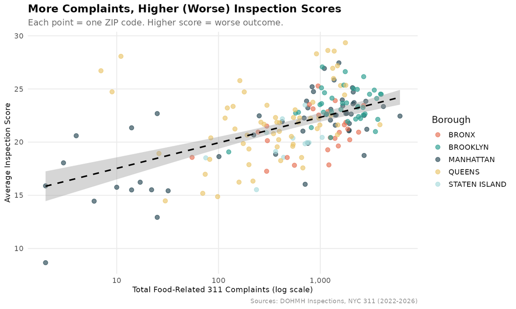

More Complaints, Higher (Worse) Inspection Scores. Each point represents one ZIP code. The dashed line shows the overall positive trend. Color indicates borough. Sources: DOHMH Inspections, NYC 311 (2022-2026).

### Complaints and Violations Reflect the Same Conditions, Not a Causal Chain

The third analysis tested whether complaint spikes actually predict future inspection deterioration, or whether complaints and violations simply co-occur because they both reflect the same persistent neighborhood conditions. We examined whether complaint volume in one month predicts inspection outcomes in the following one, two, and three months.

The lagged correlations are consistently positive but very small, ranging from 0.03 to 0.08, and none reached statistical significance after controlling for stable neighborhood characteristics. This is an important and honest null finding. It tells us that the complaint-inspection relationship is contemporaneous rather than predictive: neighborhoods with chronic food safety challenges generate both complaints and violations in the same period, rather than complaints accumulating ahead of a future wave of violations. This means 311 data is most useful as a concurrent diagnostic of neighborhood risk rather than as a pure early warning system.

### Food Establishment Complaints Are the Strongest Signal

Not all complaint types are equally informative. The fourth analysis examined which of the four complaint categories shows the strongest association with critical violation rates at the ZIP code level.

Contrary to the initial hypothesis that rodent complaints would be most predictive, Food Establishment complaints showed the strongest correlation with critical violations (r = 0.157), followed by Rodent (r = 0.116), Food Poisoning (r = 0.109), and Unsanitary Condition (r = 0.047). All four types point in the same direction. The stronger performance of Food Establishment complaints likely reflects the breadth of the category: it captures a wide range of concerns about restaurant conditions, from visible cleanliness to food handling practices, making it a more comprehensive signal about overall restaurant quality than any single specific complaint type. This breadth is also consistent with the strong aggregate association found in the second analysis: because Food Establishment complaints span so many dimensions of concern, total complaint volume driven largely by this category naturally predicts inspection scores across multiple outcome measures.

From a policy perspective, this finding suggests that Food Establishment complaints may be the most useful signal for risk-based inspection targeting, despite being less intuitively associated with critical violations than rodent sightings.

### Complaints Dramatically Accelerate Inspection Timelines

The fifth and most striking finding concerns the speed of regulatory response. We matched each food-related 311 complaint to the next inspection occurring in the same ZIP code within 180 days, then compared the resulting time-to-inspection against the baseline gap between consecutive inspections.

The baseline median gap between inspections is 315 days, roughly ten months. The median time from a food-related 311 complaint to the next inspection in the same ZIP code is just 4 days, 311 days faster. A Wilcoxon signed-rank test confirms this difference is overwhelmingly significant. Food Poisoning complaints triggered the fastest response at a median of 3 days, while Rodent complaints were slightly slower at 5 days. Across all complaint types, more than 90% of matched inspections occurred within 30 days of the complaint.

This finding should be interpreted with care. Our ZIP-level matching means some of these inspections may be routine visits to nearby restaurants rather than direct responses to the specific complaint. Even so, the magnitude of the difference is too large to be explained by coincidence. The 311 system appears to be functioning as a genuine accelerant for regulatory action, translating citizen concern into measurably faster government response.

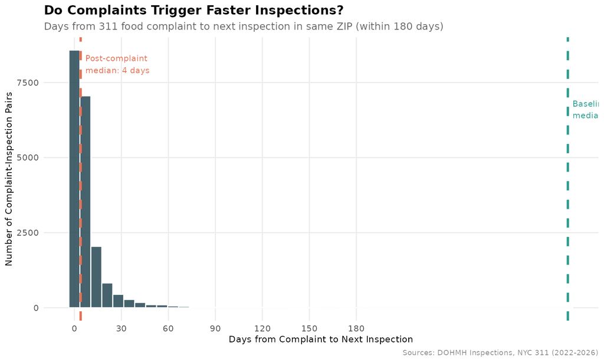

Complaints Trigger Dramatically Faster Inspections. Post-complaint inspections arrive in a median of 4 days compared to a 315-day baseline cycle. The distribution is overwhelmingly concentrated near zero. Sources: DOHMH Inspections, NYC 311 (2022-2026).

## Overall Answer to the Overarching Question

Taken together, our five analyses paint a consistent picture: yes, neighborhoods with higher complaint activity do experience systematically worse restaurant inspection outcomes.

## Prior Work and Novelty

Our project builds on three bodies of existing work. Research on restaurant inspection systems has established that grades and violation rates are meaningful predictors of foodborne illness risk (Filion and Powell, 2009; CDC, 2023). Scholarship on 311 data has shown that complaint volume reflects both genuine neighborhood conditions and socioeconomic reporting patterns (O’Brien, 2015; Kontokosta and Hong, 2021). The NYC Food Policy Center (2019) documented disparities in restaurant grading across income and race lines in New York City specifically. Taken together, these bodies of work establish the components of our analysis but do not connect them: prior studies treat inspections and complaints as separate phenomena rather than testing whether one predicts or shapes the other.

Our contribution is to link these streams directly: combining DOHMH inspection data, 311 complaint data, and demographic context to test whether complaints predict inspection outcomes and whether they accelerate regulatory response. This specific combination, tested in post-COVID New York using 2022-2026 data, has not been previously published. Prior work examined inspections and complaints separately; we test whether they are connected, how strongly, and through what mechanisms. The null temporal finding from Analysis 3, far from weakening the project, actually enriches the interpretation by ruling out a simple causal chain and pointing instead toward a concurrent signaling model, which the acceleration evidence from Analysis 5 then helps explain.

## Future Work

Several extensions would strengthen and deepen this analysis.

**Restaurant-level matching.** Our ZIP-level approach is conservative. Matching complaints to specific restaurants by address would allow a cleaner test of whether complaints trigger inspections at the establishment level, removing the noise introduced by geographic aggregation.

**Incorporating Yelp and Google reviews.** Online reviews represent a third signal of food safety concern not filtered through the 311 system. Combining citizen complaints, online reviews, and inspection outcomes could substantially improve predictive power.

**Socioeconomic moderation.** A fuller analysis would test whether the complaint-to-inspection relationship differs by neighborhood income level, specifically whether lower-income areas receive slower regulatory responses for the same complaint volume. This would surface a potential equity concern that our current analysis can only gesture toward.

**Pre- vs post-COVID comparison.** Our data begins in 2022. Comparing pre- and post-COVID inspection patterns would reveal whether the pandemic disrupted the complaint-inspection relationship and whether it has since recovered.

## Individual Reports

Full technical details for each analysis are available in the individual reports below. Each report includes all code needed to reproduce the analysis from scratch, exploratory data analysis, and extended discussion of methodology and limitations.

- [Persistent Neighborhood Complaint Activity and Repeat Critical Violations](https://carmine-montaperto.github.io/STA9750-2026-SPRING/individual_report.html)
- [Complaint Volume and Inspection Outcome Association](https://maryononye.github.io/STA9750-2026-SPRING/individual_report.html)
- [Do Food-Related 311 Complaints Predict Worse Restaurant Inspection Outcomes?](https://kevmarcel0.github.io/STA9750-2026-SPRING/individual_report_3.html)
- [Complaint Type Specificity and Critical Violation Rates](https://izabellediaz20.github.io/STA9750-2026-SPRING/individual_report.html)
- [Citizen Complaints and Regulatory Response Speed](https://kiran1051998.github.io/STA9750-2026-SPRING/Private-Project-main/Private-Project-main/all_teammate-individual_reports/t5/individual_report.html)

## References

Centers for Disease Control and Prevention. (2023). *Foodborne illness outbreaks at retail food establishments: United States.* Morbidity and Mortality Weekly Report.

Filion, K., and Powell, D. A. (2009). The use of restaurant inspection disclosure systems as a means of communicating food safety information. *Journal of Foodservice*, 20(6), 287-297.

Kontokosta, C. E., and Hong, B. (2021). Bias in smart city governance: How socioeconomic differences shape urban data generation. *Frontiers in Sustainable Cities*, 3.

New York City. (n.d.). *311 service requests from 2020 to present.* NYC Open Data. https://data.cityofnewyork.us/Social-Services/311-Service-Requests-from-2020-to-Present/erm2-nwe9

New York City Department of Health and Mental Hygiene. (n.d.). *DOHMH New York City restaurant inspection results.* NYC Open Data. https://data.cityofnewyork.us/Health/DOHMH-New-York-City-Restaurant-Inspection-Results/43nn-pn8j

New York City Food Policy Center at Hunter College. (2019, April). *Eating without reservation: Food safety and restaurant inspection in New York City.* https://cunyurbanfoodpolicy.org

O’Brien, D. T. (2015). *The urban commons: How data and technology can rebuild our communities.* Harvard University Press.